# Chapter 6: K-Nearest Neighbors (KNN)

S Zhang

2026-02-23

# 1. Introduction to K-Nearest Neighbors

K-Nearest Neighbors (KNN) is one of the simplest machine learning algorithms. It makes predictions based on the similarity of a new data point to points in the training set.

## 1.1 Core Idea

- Find the **K** most similar training examples to a new point
- For **classification**: Take a majority vote among these K neighbors
- For **regression**: Average the values of these K neighbors

**No training phase!** KNN is a “lazy learner” – it simply stores the training data and does all computation at prediction time.

## 1.2 Advantages and Disadvantages

| Advantages | Disadvantages |
| --- | --- |
| Simple and intuitive | Slow for large datasets |
| No training required | Sensitive to irrelevant features |
| Works for any number of classes | Requires feature scaling |
| Non-parametric (no assumptions) | Curse of dimensionality |
| Easily handles multi-class problems | Choosing K is critical |

# 2. How KNN Works

## 2.1 The Algorithm

For a new observation $x_0$:

1. Calculate distance to all training points
2. Identify the K closest points (neighbors)
3. For classification: assign the most common class among neighbors
4. For regression: assign the average value among neighbors

## 2.2 Distance Metrics

**Euclidean Distance** (most common):

$$d(x_i, x_j) = \sqrt{\sum_{m=1}^{p}
(x_{im} - x_{jm})^2}$$

**Manhattan Distance:**

$$d(x_i, x_j) = \sum_{m=1}^{p} |x_{im} -
x_{jm}|$$

**Minkowski Distance** (generalization):

$$d(x_i, x_j) = \left(\sum_{m=1}^{p}
|x_{im} - x_{jm}|^q\right)^{1/q}$$

**Euclidean** = straight-line distance. **Manhattan** = city-block distance. For KNN, Euclidean is the default choice.

# 3. The Iris Dataset

We’ll use the iris dataset for classification.

```r
data(iris)
str(iris)
```

```
## 'data.frame':    150 obs. of  5 variables:
##  $ Sepal.Length: num  5.1 4.9 4.7 4.6 5 5.4 4.6 5 4.4 4.9 ...
##  $ Sepal.Width : num  3.5 3 3.2 3.1 3.6 3.9 3.4 3.4 2.9 3.1 ...
##  $ Petal.Length: num  1.4 1.4 1.3 1.5 1.4 1.7 1.4 1.5 1.4 1.5 ...
##  $ Petal.Width : num  0.2 0.2 0.2 0.2 0.2 0.4 0.3 0.2 0.2 0.1 ...
##  $ Species     : Factor w/ 3 levels "setosa","versicolor",..: 1 1 1 1 1 1 1 1 1 1 ...
```

```r
# First few rows
head(iris) %>%
  kbl(caption = "Iris Dataset - First 6 Observations",
      align = 'c', booktabs = TRUE) %>%
  kable_styling(full_width = FALSE, position = "center")
```

Iris Dataset - First 6 Observations

| Sepal.Length | Sepal.Width | Petal.Length | Petal.Width | Species |
| --- | --- | --- | --- | --- |
| 5.1 | 3.5 | 1.4 | 0.2 | setosa |
| 4.9 | 3.0 | 1.4 | 0.2 | setosa |
| 4.7 | 3.2 | 1.3 | 0.2 | setosa |
| 4.6 | 3.1 | 1.5 | 0.2 | setosa |
| 5.0 | 3.6 | 1.4 | 0.2 | setosa |
| 5.4 | 3.9 | 1.7 | 0.4 | setosa |

```r
# Class distribution
table(iris$Species) %>%
  kbl(caption = "Class Distribution",
      align = 'c', booktabs = TRUE) %>%
  kable_styling(full_width = FALSE, position = "center")
```

Class Distribution

| Var1 | Freq |
| --- | --- |
| setosa | 50 |
| versicolor | 50 |
| virginica | 50 |

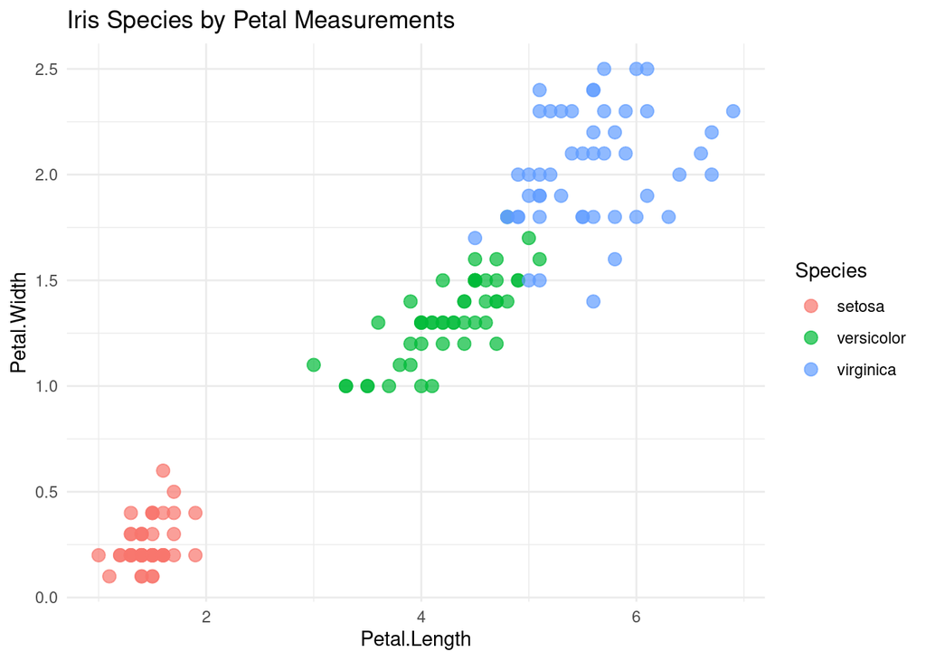

```r
# Visualize the data
ggplot(iris, aes(x = Petal.Length, y = Petal.Width, color = Species)) +
  geom_point(size = 3, alpha = 0.7) +
  labs(title = "Iris Species by Petal Measurements") +
  theme_minimal()
```

# 4. Feature Scaling – CRITICAL for KNN

KNN uses distance calculations, so features must be on the same scale!

```r
# Before scaling - features have different scales
summary(iris[, 1:4]) %>%
  kbl(caption = "Features Before Scaling - Different Ranges",
      align = 'c', booktabs = TRUE) %>%
  kable_styling(full_width = FALSE, position = "center")
```

Features Before Scaling - Different Ranges

|  | Sepal.Length | Sepal.Width | Petal.Length | Petal.Width |
| --- | --- | --- | --- | --- |
|  | Min. :4.300 | Min. :2.000 | Min. :1.000 | Min. :0.100 |
|  | 1st Qu.:5.100 | 1st Qu.:2.800 | 1st Qu.:1.600 | 1st Qu.:0.300 |
|  | Median :5.800 | Median :3.000 | Median :4.350 | Median :1.300 |
|  | Mean :5.843 | Mean :3.057 | Mean :3.758 | Mean :1.199 |
|  | 3rd Qu.:6.400 | 3rd Qu.:3.300 | 3rd Qu.:5.100 | 3rd Qu.:1.800 |
|  | Max. :7.900 | Max. :4.400 | Max. :6.900 | Max. :2.500 |

## 4.1 Standardization (Z-score)

$$x_{scaled} = \frac{x -
\mu}{\sigma}$$

```r
# Standardize the features
iris_scaled <- iris
iris_scaled[, 1:4] <- scale(iris[, 1:4])

# After scaling - all features have mean 0, sd 1
summary(iris_scaled[, 1:4]) %>%
  kbl(caption = "Features After Standardization - Mean 0, SD 1",
      align = 'c', booktabs = TRUE) %>%
  kable_styling(full_width = FALSE, position = "center")
```

Features After Standardization - Mean 0, SD 1

|  | Sepal.Length | Sepal.Width | Petal.Length | Petal.Width |
| --- | --- | --- | --- | --- |
|  | Min. :-1.86378 | Min. :-2.4258 | Min. :-1.5623 | Min. :-1.4422 |
|  | 1st Qu.:-0.89767 | 1st Qu.:-0.5904 | 1st Qu.:-1.2225 | 1st Qu.:-1.1799 |
|  | Median :-0.05233 | Median :-0.1315 | Median : 0.3354 | Median : 0.1321 |
|  | Mean : 0.00000 | Mean : 0.0000 | Mean : 0.0000 | Mean : 0.0000 |
|  | 3rd Qu.: 0.67225 | 3rd Qu.: 0.5567 | 3rd Qu.: 0.7602 | 3rd Qu.: 0.7880 |
|  | Max. : 2.48370 | Max. : 3.0805 | Max. : 1.7799 | Max. : 1.7064 |

## 4.2 Normalization (Min-Max)

$$x_{scaled} = \frac{x - min(x)}{max(x) -
min(x)}$$

```r
# Alternative: Min-max scaling (0 to 1)
normalize <- function(x) {
  return((x - min(x)) / (max(x) - min(x)))
}

iris_norm <- iris
iris_norm[, 1:4] <- as.data.frame(lapply(iris[, 1:4], normalize))

summary(iris_norm[, 1:4]) %>%
  kbl(caption = "Features After Normalization - Range 0 to 1",
      align = 'c', booktabs = TRUE) %>%
  kable_styling(full_width = FALSE, position = "center")
```

Features After Normalization - Range 0 to 1

|  | Sepal.Length | Sepal.Width | Petal.Length | Petal.Width |
| --- | --- | --- | --- | --- |
|  | Min. :0.0000 | Min. :0.0000 | Min. :0.0000 | Min. :0.00000 |
|  | 1st Qu.:0.2222 | 1st Qu.:0.3333 | 1st Qu.:0.1017 | 1st Qu.:0.08333 |
|  | Median :0.4167 | Median :0.4167 | Median :0.5678 | Median :0.50000 |
|  | Mean :0.4287 | Mean :0.4406 | Mean :0.4675 | Mean :0.45806 |
|  | 3rd Qu.:0.5833 | 3rd Qu.:0.5417 | 3rd Qu.:0.6949 | 3rd Qu.:0.70833 |
|  | Max. :1.0000 | Max. :1.0000 | Max. :1.0000 | Max. :1.00000 |

# 5. Train-Test Split

```r
set.seed(123)

# Split data (70/30)
n <- nrow(iris_scaled)
train_index <- sample(1:n, size = round(0.7 * n))

train_data <- iris_scaled[train_index, ]
test_data <- iris_scaled[-train_index, ]

# Separate features and labels
train_x <- train_data[, 1:4]
train_y <- train_data$Species
test_x <- test_data[, 1:4]
test_y <- test_data$Species

cat("Training observations:", nrow(train_data), "\n")
```

```
## Training observations: 105
```

```r
cat("Test observations:", nrow(test_data), "\n")
```

```
## Test observations: 45
```

```r
# Check class balance
train_dist <- table(train_y)
test_dist <- table(test_y)

dist_df <- data.frame(
  Species = names(train_dist),
  Train = as.vector(train_dist),
  Test = as.vector(test_dist)
)

dist_df %>%
  kbl(caption = "Class Distribution in Train/Test Splits",
      align = c('l', 'c', 'c'), booktabs = TRUE) %>%
  kable_styling(full_width = FALSE, position = "center")
```

Class Distribution in Train/Test Splits

| Species | Train | Test |
| --- | --- | --- |
| setosa | 36 | 14 |
| versicolor | 32 | 18 |
| virginica | 37 | 13 |

**Verified:** Classes are roughly balanced in both splits ✓

# 6. Basic KNN with K = 3

```r
library(class)

# Run KNN with k = 3
knn_pred <- knn(train = train_x,
                test = test_x,
                cl = train_y,
                k = 3)

# Confusion matrix
cm_k3 <- table(Predicted = knn_pred, Actual = test_y)
cm_k3 %>%
  kbl(caption = "Confusion Matrix - KNN with k = 3",
      align = 'c', booktabs = TRUE) %>%
  kable_styling(full_width = FALSE, position = "center")
```

Confusion Matrix - KNN with k = 3

|  | setosa | versicolor | virginica |
| --- | --- | --- | --- |
| setosa | 14 | 0 | 0 |
| versicolor | 0 | 17 | 1 |
| virginica | 0 | 1 | 12 |

```r
# Calculate accuracy
acc_k3 <- mean(knn_pred == test_y)
cat("Accuracy with k = 3:", round(acc_k3, 4))
```

```
## Accuracy with k = 3: 0.9556
```

**K = 3** is a common starting point. For small datasets, odd K values help avoid ties.

# 7. Effect of Different K Values

```r
# Test different K values
k_values <- c(1, 3, 5, 7, 9, 11, 15, 21)
accuracy_results <- data.frame(K = k_values, Accuracy = NA)

for(i in 1:length(k_values)) {
  pred <- knn(train = train_x, test = test_x, cl = train_y, k = k_values[i])
  accuracy_results$Accuracy[i] <- mean(pred == test_y)
}

accuracy_results %>%
  kbl(caption = "Accuracy for Different K Values",
      align = c('c', 'c'), booktabs = TRUE) %>%
  kable_styling(full_width = FALSE, position = "center")
```

Accuracy for Different K Values

| K | Accuracy |
| --- | --- |
| 1 | 0.9333333 |
| 3 | 0.9555556 |
| 5 | 0.9555556 |
| 7 | 0.9777778 |
| 9 | 0.9777778 |
| 11 | 0.9777778 |
| 15 | 0.9777778 |
| 21 | 0.9777778 |

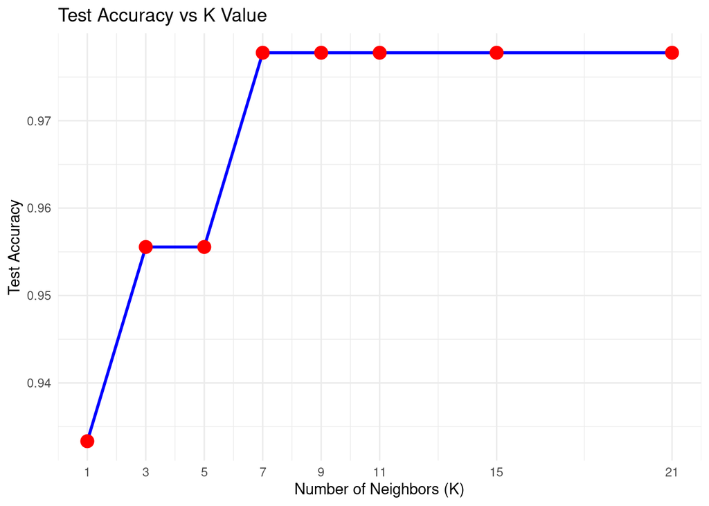

```r
# Visualize the effect of K
ggplot(accuracy_results, aes(x = K, y = Accuracy)) +
  geom_line(color = "blue", size = 1) +
  geom_point(size = 4, color = "red") +
  labs(title = "Test Accuracy vs K Value",
       x = "Number of Neighbors (K)",
       y = "Test Accuracy") +
  theme_minimal() +
  scale_x_continuous(breaks = k_values)
```

**Bias-variance tradeoff with K:** - **Small K** (e.g., K=1): Low bias, high variance (overfitting) - **Large K** (e.g., K=21): High bias, low variance (underfitting) - **Optimal K** balances both

# 8. Visualizing Decision Boundaries

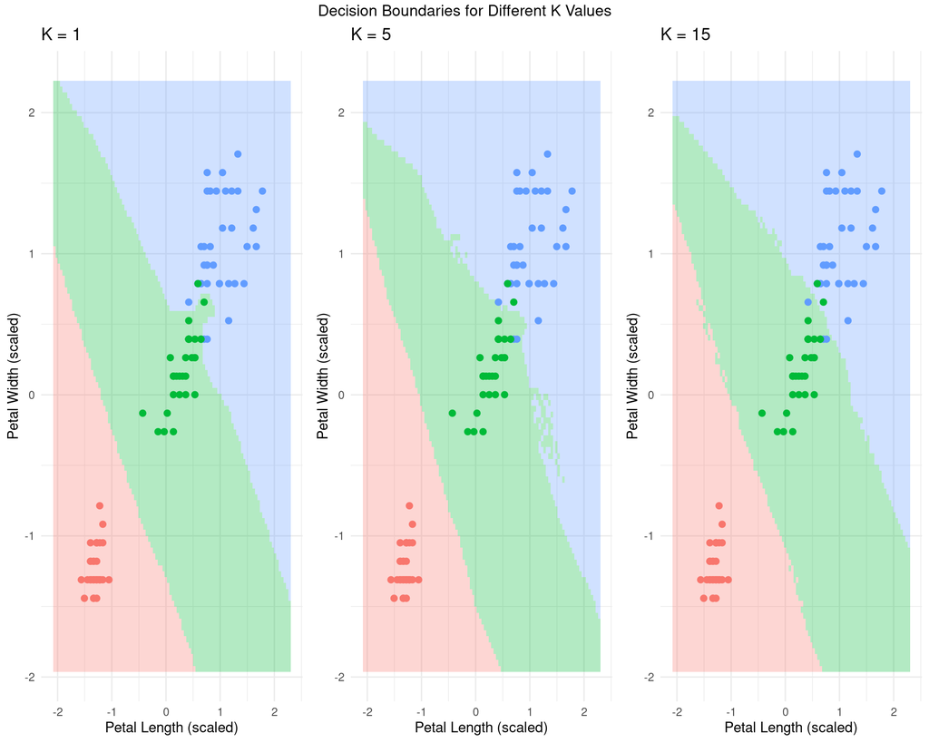

```r
# Create grid for visualization (using only 2 features for plotting)
# Make sure we're working with scaled data
train_2d <- data.frame(
  Petal.Length = train_data$Petal.Length,
  Petal.Width = train_data$Petal.Width,
  Species = train_data$Species
)

# Create grid with proper column names
grid_x <- seq(min(train_2d$Petal.Length) - 0.5,
              max(train_2d$Petal.Length) + 0.5, length = 100)
grid_y <- seq(min(train_2d$Petal.Width) - 0.5,
              max(train_2d$Petal.Width) + 0.5, length = 100)

# Create grid with EXACT column names matching training data
grid <- data.frame(
  Petal.Length = rep(grid_x, each = length(grid_y)),
  Petal.Width = rep(grid_y, length(grid_x))
)

# Plot for different K values
k_values_plot <- c(1, 5, 15)
plot_list <- list()

for(i in 1:length(k_values_plot)) {
  k <- k_values_plot[i]

  # Predict on grid - ensure column names match
  grid_pred <- knn(train = train_2d[, c("Petal.Length", "Petal.Width")],
                   test = grid[, c("Petal.Length", "Petal.Width")],
                   cl = train_2d$Species,
                   k = k)

  # Add predictions to grid
  grid$Species <- grid_pred

  p <- ggplot() +
    geom_tile(data = grid, aes(x = Petal.Length, y = Petal.Width, fill = Species),
              alpha = 0.3) +
    geom_point(data = train_2d, aes(x = Petal.Length, y = Petal.Width,
                                     color = Species), size = 2) +
    scale_fill_manual(values = c("setosa" = "#F8766D",
                                  "versicolor" = "#00BA38",
                                  "virginica" = "#619CFF")) +
    scale_color_manual(values = c("setosa" = "#F8766D",
                                   "versicolor" = "#00BA38",
                                   "virginica" = "#619CFF")) +
    labs(title = paste("K =", k),
         x = "Petal Length (scaled)", y = "Petal Width (scaled)") +
    theme_minimal() +
    theme(legend.position = "none")

  plot_list[[i]] <- p
}

# Arrange plots
grid.arrange(grobs = plot_list, ncol = 3,
             top = "Decision Boundaries for Different K Values")
```

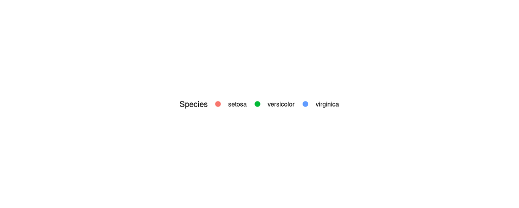

```r
library(gridExtra)
library(grid)

# Add a legend plot
legend_plot <- ggplot(train_2d, aes(x = Petal.Length, y = Petal.Width, color = Species)) +
  geom_point(size = 3) +
  scale_color_manual(values = c("setosa" = "#F8766D",
                                 "versicolor" = "#00BA38",
                                 "virginica" = "#619CFF")) +
  theme_minimal() +
  theme(legend.position = "bottom")

# Extract legend
library(cowplot)
legend <- get_legend(legend_plot)

# Display legend
grid.draw(legend)
```

# 9. Cross-Validation to Find Optimal K

```r
set.seed(123)
k_cv <- 1:20
cv_accuracy <- numeric(length(k_cv))

# 5-fold cross-validation
folds <- createFolds(train_y, k = 5, list = TRUE)

for(i in 1:length(k_cv)) {
  k <- k_cv[i]
  fold_acc <- numeric(5)

  for(f in 1:5) {
    # Split into training and validation within CV
    cv_train_x <- train_x[-folds[[f]], ]
    cv_train_y <- train_y[-folds[[f]]]
    cv_val_x <- train_x[folds[[f]], ]
    cv_val_y <- train_y[folds[[f]]]

    # Run KNN
    cv_pred <- knn(train = cv_train_x, test = cv_val_x,
                   cl = cv_train_y, k = k)
    fold_acc[f] <- mean(cv_pred == cv_val_y)
  }

  cv_accuracy[i] <- mean(fold_acc)
}

cv_results <- data.frame(K = k_cv, CV_Accuracy = cv_accuracy)
```

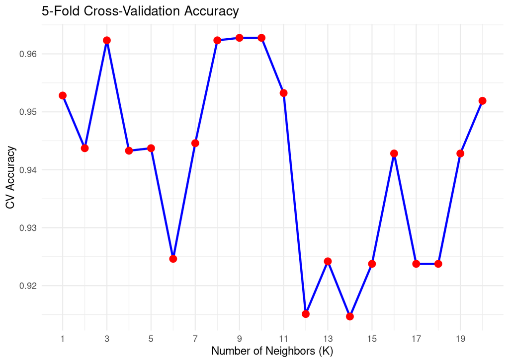

```r
# Plot CV results
ggplot(cv_results, aes(x = K, y = CV_Accuracy)) +
  geom_line(color = "blue", size = 1) +
  geom_point(size = 3, color = "red") +
  labs(title = "5-Fold Cross-Validation Accuracy",
       x = "Number of Neighbors (K)",
       y = "CV Accuracy") +
  theme_minimal() +
  scale_x_continuous(breaks = seq(1, 20, by = 2))
```

```r
# Best K
best_k <- cv_results$K[which.max(cv_results$CV_Accuracy)]
best_cv_acc <- max(cv_results$CV_Accuracy)
cat("Best K from CV:", best_k, "\n")
```

```
## Best K from CV: 9
```

```r
cat("CV Accuracy at best K:", round(best_cv_acc, 4))
```

```
## CV Accuracy at best K: 0.9628
```

**CV prevents overfitting!** The optimal K from CV generalizes better than just picking the best K on test data.

# 10. Final Model with Optimal K

```r
# Final model with best K
final_pred <- knn(train = train_x, test = test_x,
                  cl = train_y, k = best_k)

final_cm <- table(Predicted = final_pred, Actual = test_y)
final_acc <- mean(final_pred == test_y)

final_cm %>%
  kbl(caption = paste("Final Model - Test Confusion Matrix (K =", best_k,
                      ", Accuracy =", round(final_acc, 4), ")"),
      align = 'c', booktabs = TRUE) %>%
  kable_styling(full_width = FALSE, position = "center")
```

Final Model - Test Confusion Matrix (K = 9 , Accuracy = 0.9778 )

|  | setosa | versicolor | virginica |
| --- | --- | --- | --- |
| setosa | 14 | 0 | 0 |
| versicolor | 0 | 17 | 0 |
| virginica | 0 | 1 | 13 |

# 11. KNN for Regression

KNN can also predict continuous values by averaging the target values of K nearest neighbors.

## 11.1 Prepare Data for Regression

```r
# Use iris to predict Sepal.Length from other features
reg_data <- iris[, c("Sepal.Length", "Petal.Length", "Petal.Width", "Sepal.Width")]

# Split before scaling to avoid data leakage!
set.seed(123)
reg_train_idx <- sample(1:nrow(reg_data), size = round(0.7 * nrow(reg_data)))
reg_train <- reg_data[reg_train_idx, ]
reg_test <- reg_data[-reg_train_idx, ]

cat("Training observations:", nrow(reg_train), "\n")
```

```
## Training observations: 105
```

```r
cat("Test observations:", nrow(reg_test), "\n")
```

```
## Test observations: 45
```

## 11.2 Scale Features (CRITICAL!)

```r
# Calculate scaling parameters from TRAINING data only
train_means <- colMeans(reg_train[, -1])  # exclude target
train_sds <- apply(reg_train[, -1], 2, sd)

# Scale training data
reg_train_scaled <- reg_train
reg_train_scaled[, -1] <- scale(reg_train[, -1],
                                 center = train_means,
                                 scale = train_sds)

# Scale test data using SAME parameters
reg_test_scaled <- reg_test
reg_test_scaled[, -1] <- scale(reg_test[, -1],
                                center = train_means,
                                scale = train_sds)

# Check scales
cat("Training set mean after scaling:",
    round(colMeans(reg_train_scaled[, -1]), 2), "\n")
```

```
## Training set mean after scaling: 0 0 0
```

```r
cat("Test set mean after scaling:",
    round(colMeans(reg_test_scaled[, -1]), 2), "\n")
```

```
## Test set mean after scaling: -0.01 -0.01 0.04
```

**Critical:** Always scale test data using parameters from training data! Never scale training and test separately.

## 11.3 Using caret for KNN Regression

```r
library(caret)

# Prepare data with correct structure
train_for_caret <- reg_train_scaled
test_for_caret <- reg_test_scaled

# Set up cross-validation
ctrl <- trainControl(method = "cv", number = 5)

# Try different k values
set.seed(123)
knn_reg <- train(Sepal.Length ~ .,
                 data = train_for_caret,
                 method = "knn",
                 trControl = ctrl,
                 tuneGrid = data.frame(k = seq(3, 15, by = 2)))

# Best k
knn_reg$bestTune
```

```
##   k
## 2 5
```

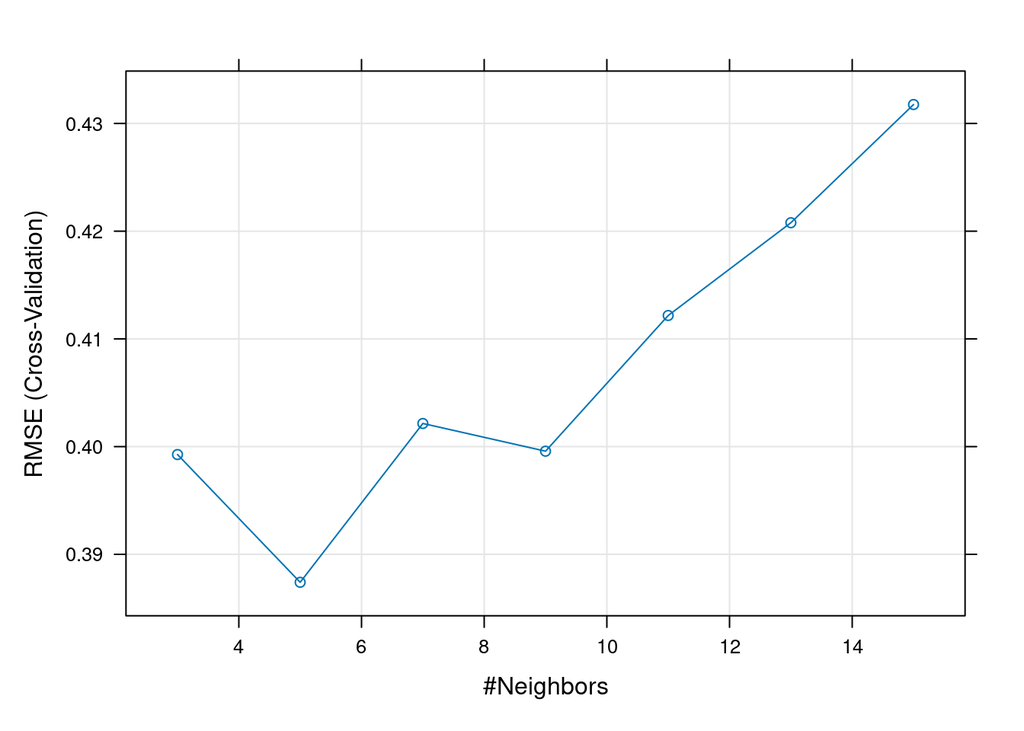

```r
# Plot tuning results
plot(knn_reg)
```

```r
# Predictions using caret
caret_pred <- predict(knn_reg, newdata = test_for_caret)
caret_rmse <- sqrt(mean((test_for_caret$Sepal.Length - caret_pred)^2))

# Compare with baseline (predicting mean)
baseline_pred <- mean(train_for_caret$Sepal.Length)
baseline_rmse <- sqrt(mean((test_for_caret$Sepal.Length - baseline_pred)^2))

comparison <- data.frame(
  Model = c("Baseline (Mean)", paste0("KNN Tuned (k=", knn_reg$bestTune$k, ")")),
  RMSE = round(c(baseline_rmse, caret_rmse), 4)
)

comparison %>%
  kbl(caption = "KNN Regression Performance",
      align = c('l', 'c'), booktabs = TRUE) %>%
  kable_styling(full_width = FALSE, position = "center") %>%
  row_spec(which.min(comparison$RMSE), bold = TRUE, background = "#e8f5e9")
```

KNN Regression Performance

| Model | RMSE |
| --- | --- |
| Baseline (Mean) | 0.7110 |
| KNN Tuned (k=5) | 0.3236 |

## 11.4 Visualizing Predictions

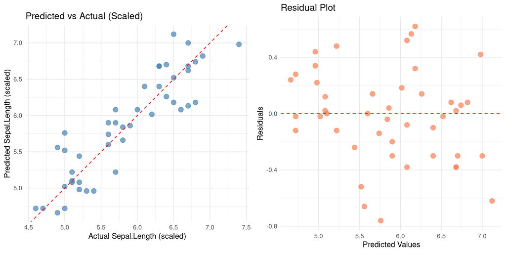

```r
# Create comparison dataframe
plot_df <- data.frame(
  Actual = test_for_caret$Sepal.Length,
  Predicted = caret_pred,
  Error = test_for_caret$Sepal.Length - caret_pred
)

# Scatter plot
p1 <- ggplot(plot_df, aes(x = Actual, y = Predicted)) +
  geom_point(size = 3, alpha = 0.7, color = "steelblue") +
  geom_abline(intercept = 0, slope = 1, linetype = "dashed", color = "red") +
  labs(title = "Predicted vs Actual (Scaled)",
       x = "Actual Sepal.Length (scaled)",
       y = "Predicted Sepal.Length (scaled)") +
  theme_minimal() +
  coord_fixed()

# Residual plot
p2 <- ggplot(plot_df, aes(x = Predicted, y = Error)) +
  geom_point(size = 3, alpha = 0.7, color = "coral") +
  geom_hline(yintercept = 0, linetype = "dashed", color = "red") +
  labs(title = "Residual Plot",
       x = "Predicted Values",
       y = "Residuals") +
  theme_minimal()

grid.arrange(p1, p2, ncol = 2)
```

```r
# If you want predictions in original scale, reverse the scaling
train_y_mean <- mean(reg_train$Sepal.Length)
train_y_sd <- sd(reg_train$Sepal.Length)

predictions_original <- caret_pred * train_y_sd + train_y_mean
actual_original <- reg_test$Sepal.Length

rmse_original <- sqrt(mean((actual_original - predictions_original)^2))
cat("RMSE in original units (cm):", round(rmse_original, 3))
```

[output not shown]

# 12. Pros and Cons in Practice

## When KNN Works Well

- **Small to medium datasets**
- **Low-dimensional data** (< 20 features)
- **Decision boundaries are irregular**
- **Interpretability isn’t critical**

## When KNN Fails

- **Large datasets** (prediction becomes slow)
- **High-dimensional data** (curse of dimensionality)
- **Irrelevant features present** (distance gets diluted)
- **Features on different scales** (forgets to scale!)

**Curse of dimensionality:** In high dimensions, all points become equally far apart – KNN breaks down!

# 13. Key Takeaways

**Essential concepts:**

1. **KNN** predicts based on similarity to K nearest neighbors
2. **Feature scaling is MANDATORY** – never skip this!
3. **Distance metrics** (Euclidean is default)
4. **Small K** → overfitting (low bias, high variance)
5. **Large K** → underfitting (high bias, low variance)
6. **Cross-validation** selects optimal K
7. Works for both **classification and regression**
8. Suffers from **curse of dimensionality**
9. Simple, interpretable, but slow for large datasets